# ENV H 570: Lab 2

Joan A. Casey, with updates from Lauren B. Wilner and Brian High

26 March, 2025

## Objective

The goal of this lab is to conduct two different environmental justice (EJ) analyses. We will perform data cleaning and then map, model, and examine the association between sociodemographic variables and oil and gas well counts in Oklahoma (Tulsa and Osage counties). We will also examine the association between historical redlining grades and oil and gas well counts in Tulsa and Osage counties.

## Setup

```r
# Clear workspace of all objects and unload all extra (non-base) packages.
rm(list = ls(all = TRUE))
if (!is.null(sessionInfo()$otherPkgs)) {
  res <- suppressWarnings(
    lapply(paste('package:', names(sessionInfo()$otherPkgs), sep=""),
           detach, character.only=TRUE, unload=TRUE, force=TRUE))
}

# Load packages, installing if needed
if(!requireNamespace("pacman", quietly = TRUE))
  install.packages("pacman")
pacman::p_load(
  conflicted,
  here,
  sf,
  janitor,
  readr,
  viridis,
  Hmisc,
  GGally,
  patchwork,
  fst,
  psych,
  spdep,
  dplyr,
  ggplot2,
  stringr,
  purrr,
  mgcv
)

# Declare a package preference for filter() with `conflicts_prefer()`:
conflicts_prefer(dplyr::filter)

# Set a seed for reproducibility
set.seed(570)
```

## Load and clean data

```r
## Wells
# Bring in data on Tulsa and Osage counties oil and gas wells from Enverus
# (https://www.enverus.com/)
## Label the well's production type, replace "other" with "disposal well"
wells <- read_csv(here("data/lab/02/tulsa_wells_no_NA_clean.csv")) %>%
  dplyr::select(-ends_with("date")) %>%
  dplyr::select(
    state,
    surface_lat_wgs84, # latitude of well
    surface_long_wgs84, # longitude of well
    well_status,
    production_type,
    comp_year # year well was completed
  ) %>%
  mutate(production_type = recode(production_type, "other" = "disposal well"))

# Look at the data and compare to your codebook in the handout
dplyr::glimpse(wells)
```

```
## Rows: 51,543
## Columns: 6
## $ state              <chr> "OK", "OK", "OK", "OK", "OK", "OK", "OK", "OK", "OK…
## $ surface_lat_wgs84  <dbl> 36.97678, 36.95173, 36.58720, 36.50471, 36.55961, 3…
## $ surface_long_wgs84 <dbl> -96.31253, -96.09905, -96.13792, -96.15443, -96.098…
## $ well_status        <chr> "inactive/abandoned", "inactive/abandoned", "inacti…
## $ production_type    <chr> "disposal well", "disposal well", "disposal well", …
## $ comp_year          <dbl> 1920, 1920, 1920, 1920, 1920, 1920, 1920, 1920, 192…
```

```r
# Let's look at well status, production type, and year of completion
wells %>% group_by(well_status) %>% summarise(n = n())
```

| well_status | n |
| --- | --- |
| active | 2628 |
| inactive/abandoned | 48915 |

```r
# Very few still active
wells %>% group_by(production_type) %>% summarise(n = n())
```

| production_type | n |
| --- | --- |
| disposal well | 37293 |
| gas | 1647 |
| oil | 12603 |

```r
# Mostly disposal wells
wells %>% group_by(comp_year) %>% summarise(n = n())
```

| comp_year | n |
| --- | --- |
| 1920 | 2652 |
| 1921 | 994 |
| 1922 | 1705 |
| 1923 | 1133 |
| 1924 | 1357 |
| 1925 | 1264 |
| 1926 | 1056 |
| 1927 | 547 |
| 1928 | 434 |
| 1929 | 349 |

[output cut: 90 more lines]

This is not a useful way to look since there are too many rows. Let’s try to create some visuals for this.

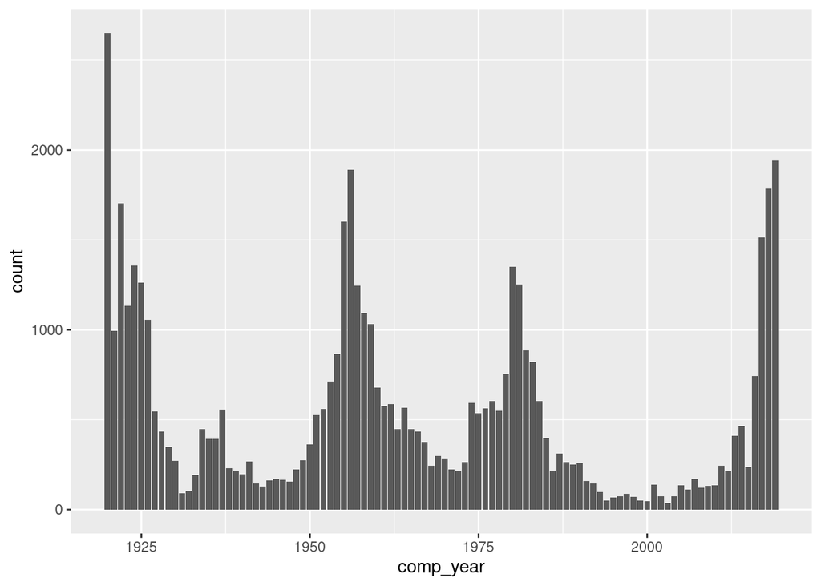

```r
# To-do: create a figure showing year of well completion (comp_year)
# Ideas include a bar chart, a line chart, something else?
# Here is an example for bar chart but please feel free to improve
wells %>% ggplot(aes(comp_year)) + geom_bar()
```

```r
## ADD HERE
```

```r
## Population density and sociodemographic data
density <- read.fst(here("data/lab/02/tract_density"))

ses <- read.fst(here("data/lab/02/tract_dem_pov.fst")) %>%
  mutate(state_fips = str_pad(statea, width=2, side="left", pad="0"),
         county_code = str_pad(countya, width=3, side="left", pad="0"),
         tract_code = str_pad(tracta, width=6, side="left", pad="0"),
         county_fips = str_c(state_fips, county_code),
         tract_fips = str_c(county_fips, tract_code),
         gisjoin = as.character(gisjoin)) %>%
  filter(county_fips %in% c("40143", "40113")) %>%
  dplyr::select(gisjoin, county_fips, tract_fips, starts_with("pct_")) %>%
  left_join(density, by = "gisjoin")

# Look at these data
ses <- glimpse(ses)
```

```
## Rows: 186
## Columns: 10
## $ gisjoin      <chr> "G4001130940001", "G4001130940002", "G4001130940003", "G4…
## $ county_fips  <chr> "40113", "40113", "40113", "40113", "40113", "40113", "40…
## $ tract_fips   <chr> "40113940001", "40113940002", "40113940003", "40113940004…
## $ pct_hispanic <dbl> 3.0753802, 3.3406244, 2.6970954, 2.1973632, 4.1571028, 2.…
## $ pct_white    <dbl> 63.513288, 56.015112, 72.904564, 74.470635, 73.170110, 14…
## $ pct_black    <dbl> 9.07571452, 2.82362299, 0.56016598, 0.39952058, 8.1611833…
## $ pct_asian    <dbl> 0.25071035, 0.13919268, 0.24896266, 0.47942469, 0.4080591…
## $ pct_amer_in  <dbl> 16.8978773, 30.0457347, 15.9336100, 15.2217339, 8.9007906…
## $ pct_pov      <dbl> 27.262693, 14.081722, 13.223301, 6.049563, 7.128657, 20.0…
## $ density      <dbl> 7.376191, 12.255204, 4.357221, 1.896307, 29.899963, 763.6…
```

```r
# Remove extra county_fips, don't need it
ses <- ses %>% dplyr::select(-county_fips)

# Descriptive statistics of tract-level SES variables, what do you observe?
ses %>%
  dplyr::select(starts_with("pct"), density) %>%
  psych::describe(na.rm = TRUE) %>%
  as.data.frame(stringsAsFactors = FALSE) %>%
  #Note that we use the dplyr::selection convention here
  dplyr::select(n, mean, sd, median, min, max)
```

|  | n | mean | sd | median | min | max |
| --- | --- | --- | --- | --- | --- | --- |
| pct_hispanic | 186 | 10.187602 | 10.256664 | 5.957597 | 0.77410274 | 54.38596 |
| pct_white | 186 | 64.047890 | 20.759327 | 72.108308 | 4.58636948 | 91.71736 |
| pct_black | 186 | 12.337710 | 19.338827 | 5.639165 | 0.09299442 | 86.96165 |
| pct_asian | 186 | 1.948787 | 2.369042 | 1.263260 | 0.00000000 | 14.55642 |
| pct_amer_in | 186 | 6.177045 | 3.706660 | 5.190191 | 0.93056550 | 30.04573 |
| pct_pov | 186 | 16.429267 | 13.289774 | 12.239390 | 0.00000000 | 65.27563 |
| density | 186 | 976.505257 | 658.935244 | 981.482601 | 1.27881085 | 2989.38107 |

```r
# Map of tract-level percent American Indian population
# Bringing in a shapefile of all census tracts in Oklahoma
# and filtering to the study area (Tulsa and Osage counties,
# FIPS = 40143 and 40113).
tract_geo <- st_read(here("data/lab/02/ok_tract_2010.shp")) %>%
  mutate(county_fips = str_c(STATEFP10, COUNTYFP10)) %>%
  filter(county_fips %in% c("40143", "40113"))
# What is the projection? Look up here: https://epsg.io/102003

# Transforming coordinates to UTM 14N projection, so we can be in meters:
# https://epsg.io/26914
# Check which UTM zone for OK here:
# https://pubs.usgs.gov/fs/2001/0077/report.pdf
tract_geo_utm14n <- st_transform(tract_geo, crs=26914)

# What is the tract identifier? A: GEOID10
glimpse(tract_geo_utm14n)
```

```
## Rows: 186
## Columns: 17
## $ STATEFP10   <chr> "40", "40", "40", "40", "40", "40", "40", "40", "40", "40"…
## $ COUNTYFP10  <chr> "143", "143", "143", "143", "143", "143", "143", "143", "1…
## $ TRACTCE10   <chr> "007624", "007632", "006703", "005806", "009004", "007625"…
## $ GEOID10     <chr> "40143007624", "40143007632", "40143006703", "40143005806"…
## $ NAME10      <chr> "76.24", "76.32", "67.03", "58.06", "90.04", "76.25", "76.…
## $ NAMELSAD10  <chr> "Census Tract 76.24", "Census Tract 76.32", "Census Tract …
## $ MTFCC10     <chr> "G5020", "G5020", "G5020", "G5020", "G5020", "G5020", "G50…
## $ FUNCSTAT10  <chr> "S", "S", "S", "S", "S", "S", "S", "S", "S", "S", "S", "S"…
## $ ALAND10     <dbl> 9830118, 2602800, 7668166, 7778049, 2547752, 3232019, 2605…
## $ AWATER10    <dbl> 1470114, 0, 2456382, 22645, 0, 484513, 0, 0, 0, 0, 462611,…
## $ INTPTLAT10  <chr> "+35.9726084", "+36.0391263", "+36.0220896", "+36.2675909"…
## $ INTPTLON10  <chr> "-095.8838046", "-095.9132023", "-095.9689411", "-095.8243…
## $ GISJOIN     <chr> "G4001430007624", "G4001430007632", "G4001430006703", "G40…
## $ Shape_area  <dbl> 11300232, 2602797, 10124554, 7800696, 2547752, 3716535, 26…
## $ Shape_len   <dbl> 14577.709, 6498.570, 18453.663, 12959.464, 6389.236, 8877.…
## $ geometry    <POLYGON [m]> POLYGON ((782356.4 3985574,..., POLYGON ((778893.5…
## $ county_fips <chr> "40143", "40143", "40143", "40143", "40143", "40143", "401…
```

```r
# What is the tract identifier in ses? A: tract_fips
glimpse(ses)
```

```
## Rows: 186
## Columns: 9
## $ gisjoin      <chr> "G4001130940001", "G4001130940002", "G4001130940003", "G4…
## $ tract_fips   <chr> "40113940001", "40113940002", "40113940003", "40113940004…
## $ pct_hispanic <dbl> 3.0753802, 3.3406244, 2.6970954, 2.1973632, 4.1571028, 2.…
## $ pct_white    <dbl> 63.513288, 56.015112, 72.904564, 74.470635, 73.170110, 14…
## $ pct_black    <dbl> 9.07571452, 2.82362299, 0.56016598, 0.39952058, 8.1611833…
## $ pct_asian    <dbl> 0.25071035, 0.13919268, 0.24896266, 0.47942469, 0.4080591…
## $ pct_amer_in  <dbl> 16.8978773, 30.0457347, 15.9336100, 15.2217339, 8.9007906…
## $ pct_pov      <dbl> 27.262693, 14.081722, 13.223301, 6.049563, 7.128657, 20.0…
## $ density      <dbl> 7.376191, 12.255204, 4.357221, 1.896307, 29.899963, 763.6…
```

```r
# holc data for EJ analysis 2
holc <- read_sf(here("data/lab/02/ok_tulsa_holc_utm15n.shp"))
glimpse(holc)
```

```
## Rows: 21
## Columns: 5
## $ name       <chr> NA, NA, NA, NA, NA, NA, NA, NA, NA, NA, NA, NA, NA, NA, NA,…
## $ holc_id    <chr> "A", "A", "A", "A", "A", "A", "A", "B", "B", "B", "B", "C",…
## $ holc_grade <chr> "A", "A", "A", "A", "A", "A", "A", "B", "B", "B", "B", "C",…
## $ area_descr <chr> "{ \"\": \"\" }", "{ \"\": \"\" }", "{ \"\": \"\" }", "{ \"…
## $ geometry   <POLYGON [m]> POLYGON ((232335.2 4000016,..., POLYGON ((238722.4 …
```

## EJ analysis 1 (SES/race/ethnicity - modern day)

Our first EJ analysis will focus on the association between percent American Indian population and oil and gas well counts in Tulsa and Osage counties.

### I. Mapping

First we will map our component datasets in order to better understand them.

Let’s take a look at our SES data and map the percent American Indian population in Tulsa and Osage counties.

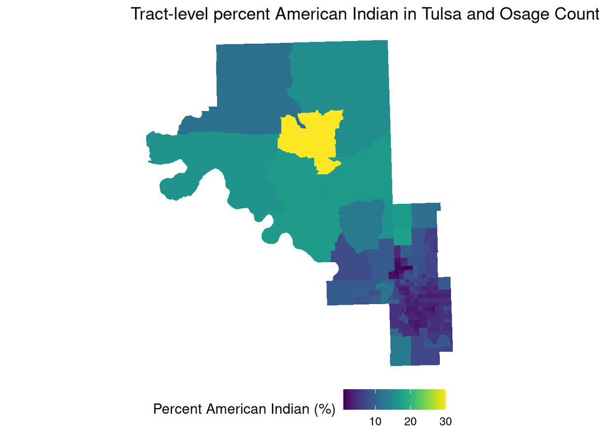

```r
# Merging data and shapefile, recall that we merge onto the spatial file to
# retain spatail aspect
ses_sp <- left_join(tract_geo_utm14n, ses, by = c("GEOID10" = "tract_fips"))

# Map of American Indian population -- let's walk through this code in
# detail together
map_pct_amer_in <- ggplot(data = ses_sp) +
  geom_sf(aes(fill = pct_amer_in), lwd = 0) +
  scale_fill_viridis(name = "Percent American Indian (%)",
                     na.value = "maroon2") +
  labs(title = "Tract-level percent American Indian in Tulsa and Osage Counties") +
  theme_void(base_size = 12) +
  # Use theme void for maps because eliminates background
  theme(legend.position = "bottom")
map_pct_amer_in
```

```r
# To-do: create a map of another census sociodemographic variable
# Try using a different color scale (change something in scale_fill_viridis)
## ADD HERE
```

Now let’s look at the distribution of oil and gas wells in Tulsa and Osage counties overlaid with our census tracts.

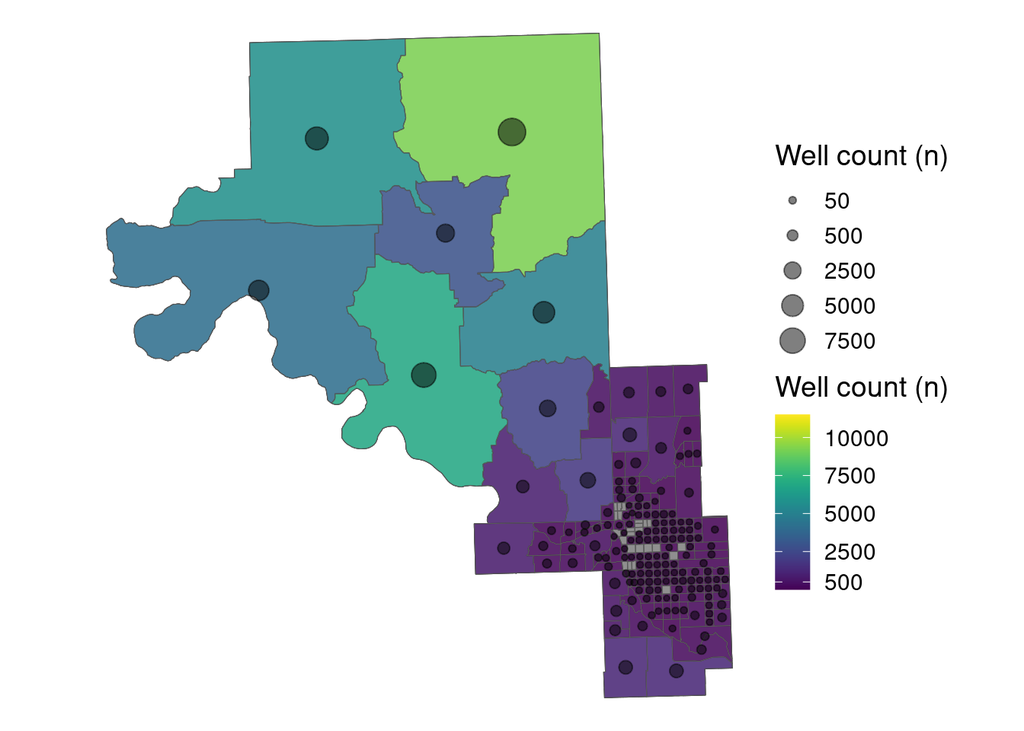

```r
# Count wells per census tract and look at correlation with % American Indian
# Create sf (spatial) object from lat/long coordinates
# + setting coordinate reference system for well data
wells_sp <- st_as_sf(wells,
                     coords = c("surface_long_wgs84", "surface_lat_wgs84"),
                     crs = 4326)

# Transforming into UTM 14N, so it's in the same projection as the census
# tract data
wells_sp_utm14n <- st_transform(wells_sp, 26914)

# Adding count of wells per census tract back to the census tract shapefile
well_count_tract <- tract_geo_utm14n %>%
  mutate(well_count = lengths(st_intersects(tract_geo_utm14n, wells_sp_utm14n))) %>%
  # Setting counts of 0 wells to NA for improved plotting
  mutate(well_count = replace(well_count, well_count == 0, NA),
  # Creating centroid coordinates
  # The st_centroid function outputs the centroid of each tract.
  # Using [[1]] and [[2]], we extract the first and second columns of that output
  # as the longitude and latitude respectively.
      lon_centroid = map_dbl(geometry, ~st_centroid(.x)[[1]]),
      lat_centroid = map_dbl(geometry, ~st_centroid(.x)[[2]]))

# Plot well count on census tract file using proportional circles
# (larger circle = more wells)
# Do you need both color and size here to show well count?
well_ct_map <- well_count_tract %>%
  filter(!well_count == 0) %>%
  ggplot() +
  geom_sf(data = ses_sp, color="black", aes(geometry = geometry),
          lwd = 0.2, alpha = 0.8) +
  geom_sf(data = well_count_tract, aes(fill = well_count), alpha = 0.85) +
  scale_fill_viridis("Well count (n)", limits = c(1, 11500),
                     breaks=c(500, 2500, 5000, 7500, 10000)) +
  geom_point(
    aes(x = lon_centroid, y = lat_centroid, size = well_count),
    fill = "grey", color = "black", alpha = .5) +
  scale_size_continuous("Well count (n)", breaks=c(50, 500, 2500, 5000, 7500))+
  theme_void(base_size=14) +
  theme(axis.text.x = element_blank(),
        axis.text.y = element_blank(),
        axis.ticks = element_blank(),
        rect=element_blank())
well_ct_map
```

```r
# To-do: change map to show just one of them
## ADD HERE
```

Now let’s look at these wells overlaid with sociodemographic information.

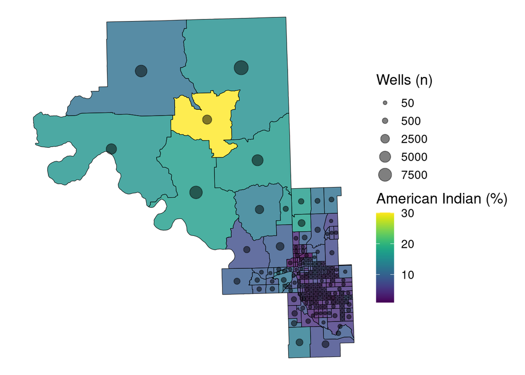

```r
# Overlaying wells with sociodemographic information
# Plot well count on census tract percent American Indian
overlay_map <- well_count_tract %>%
  filter(!well_count == 0) %>%
  ggplot() +
  geom_sf(data = ses_sp, color="black", aes(geometry = geometry,
                                            fill = pct_amer_in),
          lwd = 0.2, alpha = 0.8) +
  scale_fill_viridis("American Indian (%)") +
  geom_point(
    aes(x = lon_centroid, y = lat_centroid, size = well_count),
    fill = "grey", color = "black", alpha = .5) +
  scale_size_continuous("Wells (n)", breaks=c(50, 500, 2500, 5000, 7500))+
  theme_void(base_size=14) +
  theme(axis.text.x = element_blank(),
        axis.text.y = element_blank(),
        axis.ticks = element_blank(),
        rect=element_blank())
overlay_map
```

Finally, let’s take a closer look at Tulsa!

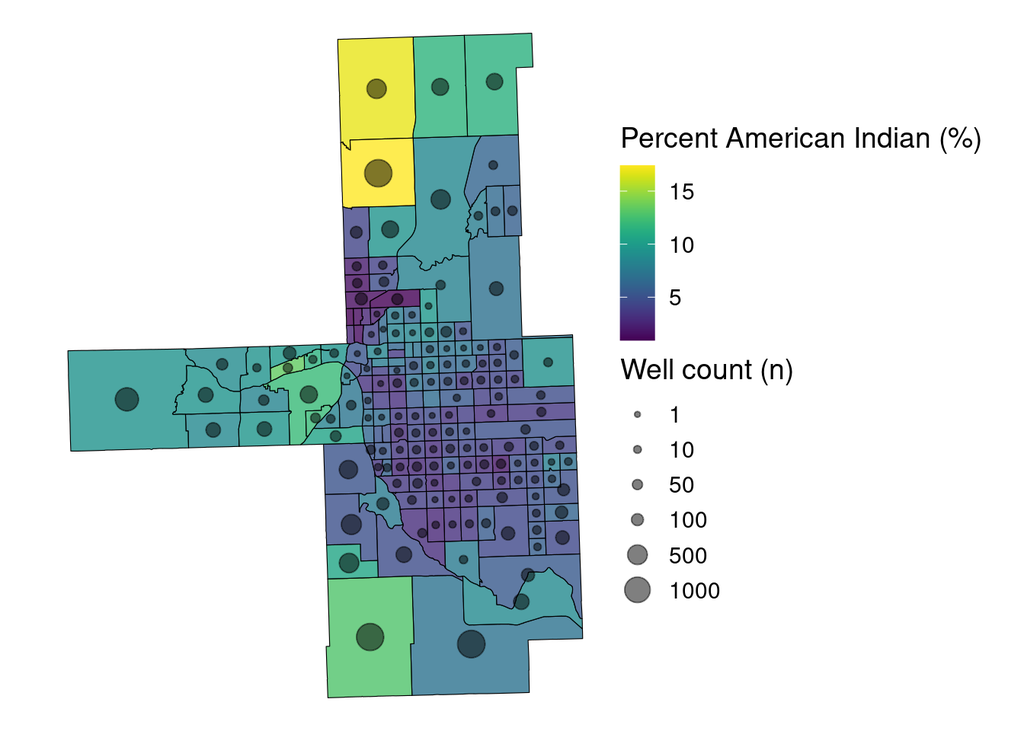

```r
# Taking a closer look at Tulsa
# Notice that census tracts are much smaller and that
# there are fewer wells overall (scale breaks change)
overlay_tulsa_map <- well_count_tract %>%
  dplyr::filter(county_fips == 40143) %>% # Filtering to Tulsa
  dplyr::filter(!well_count == 0) %>%
  ggplot() +
  geom_sf(data = ses_sp %>% dplyr::filter(county_fips == 40143),
          color="black", aes(geometry = geometry, fill = pct_amer_in),
          lwd = 0.2, alpha = 0.8) +
  scale_fill_viridis("Percent American Indian (%)") +
  scale_size_continuous("Well count (n)", breaks=c(1, 10, 50, 100, 500, 1000)) +
  geom_point(
    aes(x = lon_centroid, y = lat_centroid, size = well_count),
    fill = "grey", color = "black", alpha = .5) +
  theme_void(base_size=14) +
  theme(axis.text.x = element_blank(),
        axis.text.y = element_blank(),
        axis.ticks = element_blank(),
        rect=element_blank())

overlay_tulsa_map
```

### II. Modeling

Next, we will run a Poisson regression model to assess the association between percent American Indian population and well counts controlling for population density.

```r
# Regression model:
# Here we focus on wells built in or after 2000
# Here, we use Poisson regression to assess the association between percent
# American Indian and well counts. Restricting study period to modern day
# (starting in 2000)
wells_sp_utm14n_modern_day <- wells_sp_utm14n %>%
  filter(comp_year >= 2000)

# Counting wells built on and after 2000
well_count_tract$well_count_modern_day <-
  lengths(st_intersects(tract_geo_utm14n, wells_sp_utm14n_modern_day))

# Merging data
# Make tract_geo_utm14n not spatial so we can join
well_count_tract_nonsp <- st_drop_geometry(well_count_tract)
ct_ses <- left_join(ses_sp %>%
                      dplyr::select(GISJOIN, starts_with("pct_"), density),
                    well_count_tract_nonsp %>%
                      dplyr::select(GISJOIN, well_count_modern_day,
                                    # just keeping a few variables
                                    lon_centroid, lat_centroid),
                    by = c("GISJOIN"))

# Regression
# We run a simple Poisson model and control for population density
reg_amer_in <- glm(well_count_modern_day ~ pct_amer_in + density,
                   family="poisson", data = ct_ses)

# Summary
summary(reg_amer_in)
```

```
##
## Call:
## glm(formula = well_count_modern_day ~ pct_amer_in + density,
##     family = "poisson", data = ct_ses)
##
## Coefficients:
##               Estimate Std. Error z value Pr(>|z|)
## (Intercept)  4.976e+00  2.905e-02  171.26   <2e-16 ***
## pct_amer_in  6.657e-02  1.679e-03   39.65   <2e-16 ***
## density     -4.989e-03  7.567e-05  -65.93   <2e-16 ***
## ---
## Signif. codes:  0 '***' 0.001 '**' 0.01 '*' 0.05 '.' 0.1 ' ' 1
##
## (Dispersion parameter for poisson family taken to be 1)
##
##     Null deviance: 36580.5  on 185  degrees of freedom
## Residual deviance:  9849.5  on 183  degrees of freedom
## AIC: 10363
##
## Number of Fisher Scoring iterations: 6
```

```r
coef <- summary(reg_amer_in)$coefficients[2,1]
exp_coef <- exp(coef)
exp_coef # 1.07 <- how to interpret this value? Discuss.
```

```
## [1] 1.068837
```

```r
# Let's put all the relevant output for our coefficients into a nice table
# Extracting the coefficient for pct_amer_in and converting to a dataframe
# this will extract the coefficient, standard error, wald statistic, and p-value
coeff.table = rbind(summary(reg_amer_in)$coefficients[2,1:4])
# now we can bind them into a table
coeff.table <- as.data.frame(coeff.table, stringsAsFactors = FALSE)

# Naming the columns of the dataframe
names(coeff.table) <- c("coeff", "se", "wald", "p-value")

# Exponentiating the coefficient and computing the 95% confidence interval
output.table <- coeff.table %>%
  mutate(pt.estimate = exp(coeff)) %>%
  mutate(lci = exp(coeff - 1.96*se),
         uci = exp(coeff + 1.96*se)) %>%
  mutate(model = "pct_american_indian") %>%
  dplyr::select(model, pt.estimate, lci, uci, "p-value")

output.table
```

| model | pt.estimate | lci | uci | p-value |
| --- | --- | --- | --- | --- |
| pct_american_indian | 1.068837 | 1.065326 | 1.07236 | 0 |

This table is great to use for number plugging a manuscript or report!

### III. Diagnostics

Finally, we will assess our model diagnostics, including maping the residuals of our model to assess spatial autocorrelation and using Moran’s I to test for global clustering of residuals:

```r
# Let's look at the model Pearson residuals spatially
# Extracting the model residuals
residuals <- resid(reg_amer_in)

# Adding the residuals to the shapefile -- this makes them spatial
well_count_tract$resid <- residuals

# Also adding deciles of residuals for plotting
well_count_tract <- well_count_tract %>% mutate(decile_res=ntile(residuals, 10))

# Quick look at the residuals statistics
summary(well_count_tract$resid)
```

```
##     Min.  1st Qu.   Median     Mean  3rd Qu.     Max.
## -20.3506  -2.6640  -0.3564  -0.4161   1.6930  46.1479
```

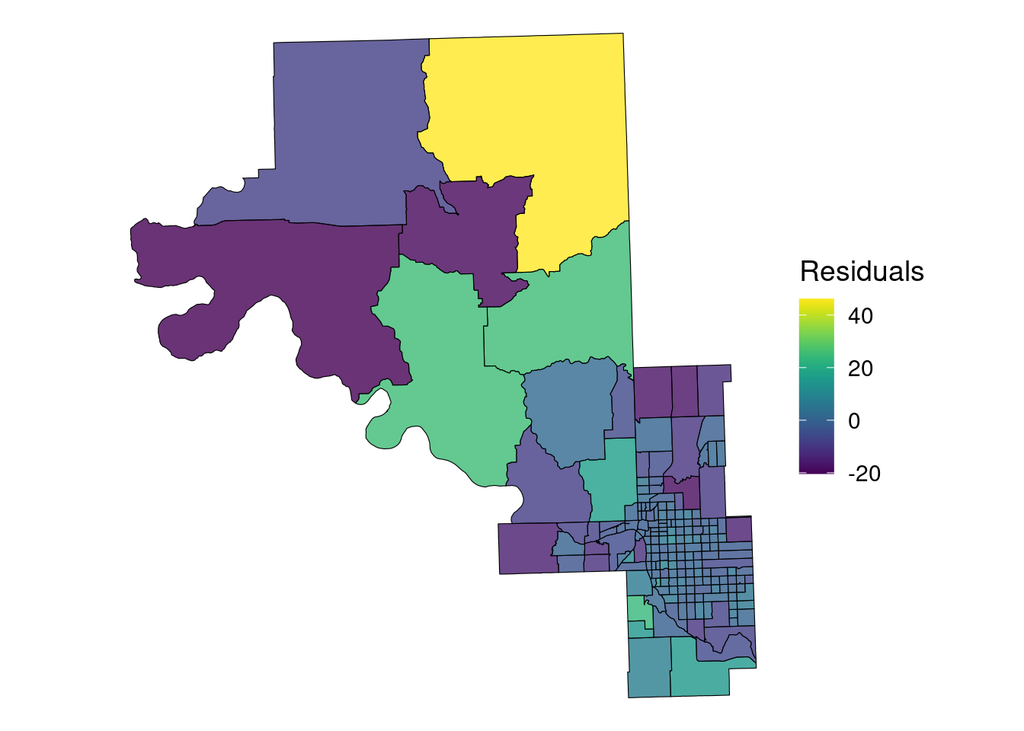

```r
# Mapping residuals
residual_ct_map <- well_count_tract %>%
  ggplot() +
  geom_sf(data = well_count_tract,
          color="black", aes(geometry = geometry, fill = resid),
          lwd = 0.2, alpha = 0.8) +
  scale_fill_viridis("Residuals") +
  theme_void(base_size=14) +
  theme(axis.text.x = element_blank(),
        axis.text.y = element_blank(),
        axis.ticks = element_blank(),
        rect=element_blank())
residual_ct_map
```

```r
# Moran's I - test of global clustering of residuals
# Creating neighbor matrix - this describes which polygons are neighbors of
# other polygons
nb <- poly2nb(well_count_tract, queen=TRUE)

# Assigning spatial weights based on neighbors
nb_lw <- nb2listw(nb, style="B")

# Running Moran's I test -- values will range from -1 to 1
moran.test(well_count_tract$resid, nb_lw)
```

```
##
##  Moran I test under randomisation
##
## data:  well_count_tract$resid
## weights: nb_lw
##
## Moran I statistic standard deviate = 2.5649, p-value = 0.00516
## alternative hypothesis: greater
## sample estimates:
## Moran I statistic       Expectation          Variance
##       0.092838318      -0.005405405       0.001467128
```

We see that we get a p-value <0.05, indicating support for non-randomly distributed residuals.

### IV. Model rerun

Based on these diagnostics, let’s try to rerun our model with a spline on census tract centroid lat/long and see how it changes things.

```r
# Let's start with a rerun with a spline on census tract centroid lat/long
# and see how it changes things

# We run a simple Poisson model and control for population density
# now with a spline on census tract centroid lat/long
reg_amer_in_sp <- gam(well_count_modern_day ~ pct_amer_in + density +
                        s(lat_centroid, lon_centroid),
                  family="poisson", data = ct_ses)

# Do results change?
summary(reg_amer_in_sp)
```

```
##
## Family: poisson
## Link function: log
##
## Formula:
## well_count_modern_day ~ pct_amer_in + density + s(lat_centroid,
##     lon_centroid)
##
## Parametric coefficients:
##               Estimate Std. Error z value Pr(>|z|)
## (Intercept)  3.0566810  0.1169965  26.126  < 2e-16 ***
## pct_amer_in  0.0732645  0.0100155   7.315 2.57e-13 ***
## density     -0.0023799  0.0001075 -22.134  < 2e-16 ***
## ---
## Signif. codes:  0 '***' 0.001 '**' 0.01 '*' 0.05 '.' 0.1 ' ' 1
##
## Approximate significance of smooth terms:
##                                edf Ref.df Chi.sq p-value
## s(lat_centroid,lon_centroid) 28.79  28.99   6843  <2e-16 ***
## ---
## Signif. codes:  0 '***' 0.001 '**' 0.01 '*' 0.05 '.' 0.1 ' ' 1
##
## R-sq.(adj) =  0.989   Deviance explained = 96.1%
## UBRE = 6.9949  Scale est. = 1         n = 186
```

```r
coef <- summary(reg_amer_in_sp)[1]$p.coeff[2]
# note we pull this out slightly differently because the model output changed because of our spline
exp_coef <- exp(coef) # 1.08

# Let's look at the residuals now
# Let's look at the model Pearson residuals spatially
# Extracting the model residuals
residuals <- resid(reg_amer_in_sp)

# Adding the residuals to the shapefile -- this makes them spatial
well_count_tract$resid <- residuals

# Also adding deciles of residuals for plotting
well_count_tract <- well_count_tract %>% mutate(decile_res=ntile(residuals, 10))

# Quick look at the residuals statistics
summary(well_count_tract$resid)
```

```
##    Min. 1st Qu.  Median    Mean 3rd Qu.    Max.
## -9.8965 -1.5796 -0.6739 -0.2684  0.7135 10.0587
```

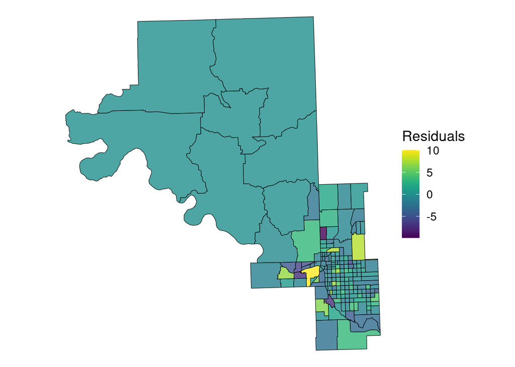

```r
# Mapping residuals
residual_ct_map2 <- well_count_tract %>%
  ggplot() +
  geom_sf(data = well_count_tract,
          color="black", aes(geometry = geometry, fill = resid),
          lwd = 0.2, alpha = 0.8) +
  scale_fill_viridis("Residuals") +
  theme_void(base_size=14) +
  theme(axis.text.x = element_blank(),
        axis.text.y = element_blank(),
        axis.ticks = element_blank(),
        rect=element_blank())
residual_ct_map2
```

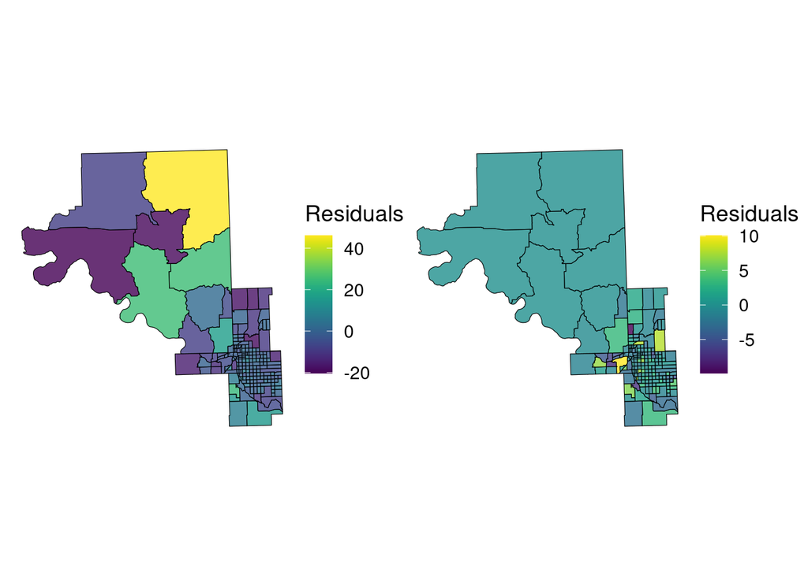

```r
# Plot the residual maps side by side
residual_ct_map + residual_ct_map2
```

Which residual map do you think is better? Why?

We can also look at Moran’s I again for global clustering of residuals.

```r
# Moran's I - test of global clustering of residuals
# Creating neighbor matrix - this describes which polygons are neighbors of
# other polygons
nb <- poly2nb(well_count_tract, queen=TRUE)

# Assigning spatial weights based on neighbors
nb_lw <- nb2listw(nb, style="B")

# Running Moran's I test -- values will range from -1 to 1
moran.test(well_count_tract$resid, nb_lw)
```

```
##
##  Moran I test under randomisation
##
## data:  well_count_tract$resid
## weights: nb_lw
##
## Moran I statistic standard deviate = -1.6929, p-value = 0.9548
## alternative hypothesis: greater
## sample estimates:
## Moran I statistic       Expectation          Variance
##      -0.071768779      -0.005405405       0.001536635
```

What does this Moran’s I and p-value indicate?